# LGMVIP-DATA-SCIENCE

LetsGrowMore Virtual Internship Program ( JAN 2023 - FEB 2023 )

Author : MANISHA SHARMA

Task 1 : Iris Flowers Classification ML Project

Level : Beginner

# Iris Flower Classification Project using Machine Learning

problem statement :- This particular ML project is usually referred to as the “Hello World” of Machine Learning. The iris flowers dataset contains numeric attributes, and it is perfect for beginners to learn about supervised ML algorithms, mainly how to load and handle data. Also, since this is a small dataset, it can easily fit in memory without requiring special transformations or scaling capabilities.

Watch Tutorial from here: https://youtu.be/CBCfOTePVPo  
Datasetlink : http://archive.ics.uci.edu/ml/datasets/Iris

Iris flower classification is a very popular machine learning project. The iris dataset contains 3 classes of flowers:- 1 Versicolor, 2 Setosa, 3 Virginica, and class contains 4 features:- 1 Sepal_length, 2 Sepal_width, 3 Petal_length, 4 Petal_width The aim of the iris flower classification is to predict flowers based on their specific features.

# Prerequisites:

1. Numpy- 1.19.3
2. Matplotlib- 3.3.2
3. Seaborn – 0.11.1
4. Pandas – 1.2.4
5. Scikit-learn – 0.24.2

# Steps to Classify Iris Flower:

1. Load the data
2. Analyze and visualize the dataset
3. Model training.
4. Model Evaluation.
5. Testing the model.

```python
import numpy as np    #used for computational operations
import matplotlib.pyplot as plt   #data visualization
import seaborn as sns         #data visualization
import pandas as pd          #load data from local database,csv file etc
```

```python
columns = ['Sepal length', 'Sepal width', 'Petal length', 'Petal width', 'Class_labels']
# Load the data
iris = pd.read_csv('C://Users//Lenovo//OneDrive//Attachments//manisha//project//external project//archive//iris_data.csv', names=columns)
iris.head()
```

|  | Sepal length | Sepal width | Petal length | Petal width | Class_labels |
| --- | --- | --- | --- | --- | --- |
| 0 | sepal_length | sepal_width | petal_length | petal_width | species |
| 1 | 5.1 | 3.5 | 1.4 | 0.2 | Iris-setosa |
| 2 | 4.9 | 3 | 1.4 | 0.2 | Iris-setosa |
| 3 | 4.7 | 3.2 | 1.3 | 0.2 | Iris-setosa |
| 4 | 4.6 | 3.1 | 1.5 | 0.2 | Iris-setosa |

load the data using pd.read_csv() and set the column name as per the iris data information. Pd.read_csv reads CSV files(CSV stands for comma separated value). iris.head() only shows the first 5 rows from the data set table.

```python
# Some basic statistical analysis about the data
iris.describe()
```

|  | Sepal length | Sepal width | Petal length | Petal width | Class_labels |
| --- | --- | --- | --- | --- | --- |
| count | 151 | 151 | 151 | 151 | 151 |
| unique | 36 | 24 | 44 | 23 | 4 |
| top | 5 | 3 | 1.5 | 0.2 | Iris-setosa |
| freq | 10 | 26 | 14 | 28 | 50 |

# Let’s visualize the dataset.

```python
! pip install --upgrade seaborn
```

[output not shown]

```python
print('Dataset Shape'==(),
      'Dataset Columns'==(),
      'Data Description'==(),
      'Does Data contains null value'==(),
      format('iris.shape(),iris.columns(),iris.describe(),iris.isnull(),iris.all()'))
```

```
False False False False iris.shape(),iris.columns(),iris.describe(),iris.isnull(),iris.all()
```

```python
iris['Class_labels'].value_counts()
```

```
Iris-setosa        50
Iris-versicolor    50
Iris-virginica     50
species             1
Name: Class_labels, dtype: int64
```

```python
print (iris.head(10))
```

```
   Sepal length  Sepal width  Petal length  Petal width Class_labels
0  sepal_length  sepal_width  petal_length  petal_width      species
1           5.1          3.5           1.4          0.2  Iris-setosa
2           4.9            3           1.4          0.2  Iris-setosa
3           4.7          3.2           1.3          0.2  Iris-setosa
4           4.6          3.1           1.5          0.2  Iris-setosa
5             5          3.6           1.4          0.2  Iris-setosa
6           5.4          3.9           1.7          0.4  Iris-setosa
7           4.6          3.4           1.4          0.3  Iris-setosa
8             5          3.4           1.5          0.2  Iris-setosa
9           4.4          2.9           1.4          0.2  Iris-setosa
```

```python
print (iris.tail(10))
```

```
    Sepal length Sepal width Petal length Petal width    Class_labels
141          6.7         3.1          5.6         2.4  Iris-virginica
142          6.9         3.1          5.1         2.3  Iris-virginica
143          5.8         2.7          5.1         1.9  Iris-virginica
144          6.8         3.2          5.9         2.3  Iris-virginica
145          6.7         3.3          5.7         2.5  Iris-virginica
146          6.7           3          5.2         2.3  Iris-virginica
147          6.3         2.5            5         1.9  Iris-virginica
148          6.5           3          5.2           2  Iris-virginica
149          6.2         3.4          5.4         2.3  Iris-virginica
150          5.9           3          5.1         1.8  Iris-virginica
```

```python
print (iris.shape)
```

```
(151, 5)
```

```python
print("First 5 entries in the dataset:\n")
iris.head()
```

```
First 5 entries in the dataset:
```

|  | Sepal length | Sepal width | Petal length | Petal width | Class_labels |
| --- | --- | --- | --- | --- | --- |
| 0 | sepal_length | sepal_width | petal_length | petal_width | species |
| 1 | 5.1 | 3.5 | 1.4 | 0.2 | Iris-setosa |
| 2 | 4.9 | 3 | 1.4 | 0.2 | Iris-setosa |
| 3 | 4.7 | 3.2 | 1.3 | 0.2 | Iris-setosa |
| 4 | 4.6 | 3.1 | 1.5 | 0.2 | Iris-setosa |

```python
print("\nMetrics observed from the dataset:\n")
iris.describe()
```

```
Metrics observed from the dataset:
```

|  | Sepal length | Sepal width | Petal length | Petal width | Class_labels |
| --- | --- | --- | --- | --- | --- |
| count | 151 | 151 | 151 | 151 | 151 |
| unique | 36 | 24 | 44 | 23 | 4 |
| top | 5 | 3 | 1.5 | 0.2 | Iris-setosa |
| freq | 10 | 26 | 14 | 28 | 50 |

```python
iris.sample(10)
```

|  | Sepal length | Sepal width | Petal length | Petal width | Class_labels |
| --- | --- | --- | --- | --- | --- |
| 60 | 5.2 | 2.7 | 3.9 | 1.4 | Iris-versicolor |
| 53 | 6.9 | 3.1 | 4.9 | 1.5 | Iris-versicolor |
| 108 | 7.3 | 2.9 | 6.3 | 1.8 | Iris-virginica |
| 52 | 6.4 | 3.2 | 4.5 | 1.5 | Iris-versicolor |
| 30 | 4.7 | 3.2 | 1.6 | 0.2 | Iris-setosa |
| 133 | 6.4 | 2.8 | 5.6 | 2.2 | Iris-virginica |
| 24 | 5.1 | 3.3 | 1.7 | 0.5 | Iris-setosa |
| 102 | 5.8 | 2.7 | 5.1 | 1.9 | Iris-virginica |
| 35 | 4.9 | 3.1 | 1.5 | 0.1 | Iris-setosa |
| 67 | 5.6 | 3 | 4.5 | 1.5 | Iris-versicolor |

```python
iris.columns
```

```
Index(['Sepal length', 'Sepal width', 'Petal length', 'Petal width',
       'Class_labels'],
      dtype='object')
```

```python
#data[start:end]
#start is inclusive whereas end is exclusive
print(iris[10:21])
# it will print the rows from 10 to 20.

# you can also save it in a variable for further use in analysis
sliced_iris=iris[10:21]
print(sliced_iris)
```

```
   Sepal length Sepal width Petal length Petal width Class_labels
10          4.9         3.1          1.5         0.1  Iris-setosa
11          5.4         3.7          1.5         0.2  Iris-setosa
12          4.8         3.4          1.6         0.2  Iris-setosa
13          4.8           3          1.4         0.1  Iris-setosa
14          4.3           3          1.1         0.1  Iris-setosa
15          5.8           4          1.2         0.2  Iris-setosa
16          5.7         4.4          1.5         0.4  Iris-setosa
17          5.4         3.9          1.3         0.4  Iris-setosa
18          5.1         3.5          1.4         0.3  Iris-setosa
19          5.7         3.8          1.7         0.3  Iris-setosa
20          5.1         3.8          1.5         0.3  Iris-setosa
   Sepal length Sepal width Petal length Petal width Class_labels
10          4.9         3.1          1.5         0.1  Iris-setosa
11          5.4         3.7          1.5         0.2  Iris-setosa
12          4.8         3.4          1.6         0.2  Iris-setosa
13          4.8           3          1.4         0.1  Iris-setosa
14          4.3           3          1.1         0.1  Iris-setosa
15          5.8           4          1.2         0.2  Iris-setosa
16          5.7         4.4          1.5         0.4  Iris-setosa
17          5.4         3.9          1.3         0.4  Iris-setosa
18          5.1         3.5          1.4         0.3  Iris-setosa
19          5.7         3.8          1.7         0.3  Iris-setosa
20          5.1         3.8          1.5         0.3  Iris-setosa
```

```python
#here in the case of Iris dataset
#we will save it in a another variable named "specific_data"

specific_iris=iris["Class_labels"]
#data[["column_name1","column_name2","column_name3"]]

#now we will print the first 10 columns of the specific_data dataframe.
print(specific_iris.head(30))
```

```
0         species
1     Iris-setosa
2     Iris-setosa
3     Iris-setosa
4     Iris-setosa
5     Iris-setosa
6     Iris-setosa
7     Iris-setosa
8     Iris-setosa
9     Iris-setosa
10    Iris-setosa
11    Iris-setosa
12    Iris-setosa
13    Iris-setosa
14    Iris-setosa
```

[output cut: 16 more lines]

```python
#here we will use iloc

iris.iloc[5]
#it will display records only with species "Iris-setosa".
iris.loc[iris["Class_labels"] == "Iris-setosa"]
```

|  | Sepal length | Sepal width | Petal length | Petal width | Class_labels |
| --- | --- | --- | --- | --- | --- |
| 1 | 5.1 | 3.5 | 1.4 | 0.2 | Iris-setosa |
| 2 | 4.9 | 3 | 1.4 | 0.2 | Iris-setosa |
| 3 | 4.7 | 3.2 | 1.3 | 0.2 | Iris-setosa |
| 4 | 4.6 | 3.1 | 1.5 | 0.2 | Iris-setosa |
| 5 | 5 | 3.6 | 1.4 | 0.2 | Iris-setosa |
| 6 | 5.4 | 3.9 | 1.7 | 0.4 | Iris-setosa |
| 7 | 4.6 | 3.4 | 1.4 | 0.3 | Iris-setosa |
| 8 | 5 | 3.4 | 1.5 | 0.2 | Iris-setosa |
| 9 | 4.4 | 2.9 | 1.4 | 0.2 | Iris-setosa |
| 10 | 4.9 | 3.1 | 1.5 | 0.1 | Iris-setosa |
| 11 | 5.4 | 3.7 | 1.5 | 0.2 | Iris-setosa |
| 12 | 4.8 | 3.4 | 1.6 | 0.2 | Iris-setosa |
| 13 | 4.8 | 3 | 1.4 | 0.1 | Iris-setosa |
| 14 | 4.3 | 3 | 1.1 | 0.1 | Iris-setosa |
| 15 | 5.8 | 4 | 1.2 | 0.2 | Iris-setosa |
| 16 | 5.7 | 4.4 | 1.5 | 0.4 | Iris-setosa |
| 17 | 5.4 | 3.9 | 1.3 | 0.4 | Iris-setosa |
| 18 | 5.1 | 3.5 | 1.4 | 0.3 | Iris-setosa |
| 19 | 5.7 | 3.8 | 1.7 | 0.3 | Iris-setosa |
| 20 | 5.1 | 3.8 | 1.5 | 0.3 | Iris-setosa |
| 21 | 5.4 | 3.4 | 1.7 | 0.2 | Iris-setosa |
| 22 | 5.1 | 3.7 | 1.5 | 0.4 | Iris-setosa |
| 23 | 4.6 | 3.6 | 1 | 0.2 | Iris-setosa |
| 24 | 5.1 | 3.3 | 1.7 | 0.5 | Iris-setosa |
| 25 | 4.8 | 3.4 | 1.9 | 0.2 | Iris-setosa |
| 26 | 5 | 3 | 1.6 | 0.2 | Iris-setosa |
| 27 | 5 | 3.4 | 1.6 | 0.4 | Iris-setosa |
| 28 | 5.2 | 3.5 | 1.5 | 0.2 | Iris-setosa |
| 29 | 5.2 | 3.4 | 1.4 | 0.2 | Iris-setosa |
| 30 | 4.7 | 3.2 | 1.6 | 0.2 | Iris-setosa |
| 31 | 4.8 | 3.1 | 1.6 | 0.2 | Iris-setosa |
| 32 | 5.4 | 3.4 | 1.5 | 0.4 | Iris-setosa |
| 33 | 5.2 | 4.1 | 1.5 | 0.1 | Iris-setosa |
| 34 | 5.5 | 4.2 | 1.4 | 0.2 | Iris-setosa |
| 35 | 4.9 | 3.1 | 1.5 | 0.1 | Iris-setosa |
| 36 | 5 | 3.2 | 1.2 | 0.2 | Iris-setosa |
| 37 | 5.5 | 3.5 | 1.3 | 0.2 | Iris-setosa |
| 38 | 4.9 | 3.1 | 1.5 | 0.1 | Iris-setosa |
| 39 | 4.4 | 3 | 1.3 | 0.2 | Iris-setosa |
| 40 | 5.1 | 3.4 | 1.5 | 0.2 | Iris-setosa |
| 41 | 5 | 3.5 | 1.3 | 0.3 | Iris-setosa |
| 42 | 4.5 | 2.3 | 1.3 | 0.3 | Iris-setosa |
| 43 | 4.4 | 3.2 | 1.3 | 0.2 | Iris-setosa |
| 44 | 5 | 3.5 | 1.6 | 0.6 | Iris-setosa |
| 45 | 5.1 | 3.8 | 1.9 | 0.4 | Iris-setosa |
| 46 | 4.8 | 3 | 1.4 | 0.3 | Iris-setosa |
| 47 | 5.1 | 3.8 | 1.6 | 0.2 | Iris-setosa |
| 48 | 4.6 | 3.2 | 1.4 | 0.2 | Iris-setosa |
| 49 | 5.3 | 3.7 | 1.5 | 0.2 | Iris-setosa |
| 50 | 5 | 3.3 | 1.4 | 0.2 | Iris-setosa |

```python
#In this dataset we will work on the Species column, it will count number of times a particular species has occurred.
iris["Class_labels"].value_counts()
#it will display in descending order.
```

```
Iris-setosa        50
Iris-versicolor    50
Iris-virginica     50
species             1
Name: Class_labels, dtype: int64
```

```python
# iris["column_name"].sum()
sum_iris = iris["Sepal length"].sum()
print("Sum:",sum_iris)
```

[output not shown]

```python
iris.corr(method='pearson')
```

[output not shown]

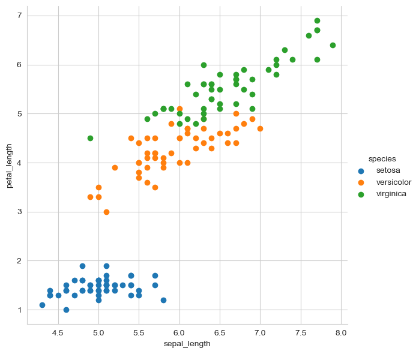

```python
import seaborn as sns

iris = sns.load_dataset('iris')

# style used as a theme of graph
# for example if we want black
# graph with grid then write "darkgrid"
sns.set_style("whitegrid")

# sepal_length, petal_length are iris
# feature data height used to define
# Height of graph whereas hue store the
# class of iris dataset.
sns.FacetGrid(iris, hue ="species",
			height = 6).map(plt.scatter,
							'sepal_length',
							'petal_length').add_legend()
```

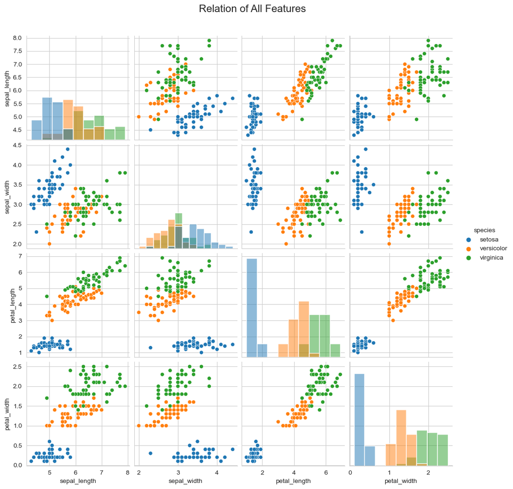

```python
pplot = sns.pairplot(iris, hue =  'species', diag_kind = 'hist')
pplot.fig.suptitle("Relation of All Features ", y = 1.05, fontsize = 16)
plt.show()
```

```python
# Segregating The Independent & Dependent Variables
X=iris.iloc[:,:-1].values
Y=iris.iloc[:,-1].values
print(X)
```

```
[[5.1 3.5 1.4 0.2]
 [4.9 3.  1.4 0.2]
 [4.7 3.2 1.3 0.2]
 [4.6 3.1 1.5 0.2]
 [5.  3.6 1.4 0.2]
 [5.4 3.9 1.7 0.4]
 [4.6 3.4 1.4 0.3]
 [5.  3.4 1.5 0.2]
 [4.4 2.9 1.4 0.2]
 [4.9 3.1 1.5 0.1]
 [5.4 3.7 1.5 0.2]
 [4.8 3.4 1.6 0.2]
 [4.8 3.  1.4 0.1]
 [4.3 3.  1.1 0.1]
 [5.8 4.  1.2 0.2]
 [5.7 4.4 1.5 0.4]
 [5.4 3.9 1.3 0.4]
 [5.1 3.5 1.4 0.3]
 [5.7 3.8 1.7 0.3]
 [5.1 3.8 1.5 0.3]
 [5.4 3.4 1.7 0.2]
 [5.1 3.7 1.5 0.4]
 [4.6 3.6 1.  0.2]
 [5.1 3.3 1.7 0.5]
 [4.8 3.4 1.9 0.2]
 [5.  3.  1.6 0.2]
 [5.  3.4 1.6 0.4]
 [5.2 3.5 1.5 0.2]
 [5.2 3.4 1.4 0.2]
 [4.7 3.2 1.6 0.2]
 [4.8 3.1 1.6 0.2]
 [5.4 3.4 1.5 0.4]
 [5.2 4.1 1.5 0.1]
 [5.5 4.2 1.4 0.2]
 [4.9 3.1 1.5 0.2]
 [5.  3.2 1.2 0.2]
 [5.5 3.5 1.3 0.2]
 [4.9 3.6 1.4 0.1]
 [4.4 3.  1.3 0.2]
 [5.1 3.4 1.5 0.2]
```

[output cut: 95 more lines]

```
 [7.7 3.  6.1 2.3]
 [6.3 3.4 5.6 2.4]
 [6.4 3.1 5.5 1.8]
 [6.  3.  4.8 1.8]
 [6.9 3.1 5.4 2.1]
 [6.7 3.1 5.6 2.4]
 [6.9 3.1 5.1 2.3]
 [5.8 2.7 5.1 1.9]
 [6.8 3.2 5.9 2.3]
 [6.7 3.3 5.7 2.5]
 [6.7 3.  5.2 2.3]
 [6.3 2.5 5.  1.9]
 [6.5 3.  5.2 2. ]
 [6.2 3.4 5.4 2.3]
 [5.9 3.  5.1 1.8]]
```

```python
# Split The Dataset Into Training Set & Test Set
from sklearn.model_selection import train_test_split
X_train,X_test,Y_train,Y_test=train_test_split(X,Y,test_size=0.2)
```

```python
print(X_train)
```

```
[[5.7 2.6 3.5 1. ]
 [6.9 3.2 5.7 2.3]
 [4.8 3.4 1.9 0.2]
 [5.1 3.8 1.9 0.4]
 [6.9 3.1 5.1 2.3]
 [6.5 3.2 5.1 2. ]
 [5.6 3.  4.5 1.5]
 [5.8 4.  1.2 0.2]
 [6.1 2.9 4.7 1.4]
 [5.2 3.5 1.5 0.2]
 [4.6 3.6 1.  0.2]
 [5.5 3.5 1.3 0.2]
 [5.1 3.4 1.5 0.2]
 [7.4 2.8 6.1 1.9]
 [6.3 2.9 5.6 1.8]
 [5.  3.  1.6 0.2]
 [6.9 3.1 4.9 1.5]
 [5.7 2.8 4.1 1.3]
 [4.4 2.9 1.4 0.2]
 [6.  2.2 4.  1. ]
 [5.6 3.  4.1 1.3]
 [6.3 3.3 4.7 1.6]
 [4.9 3.1 1.5 0.2]
 [4.7 3.2 1.6 0.2]
 [5.5 2.5 4.  1.3]
 [7.6 3.  6.6 2.1]
 [5.6 2.7 4.2 1.3]
 [5.  3.3 1.4 0.2]
 [6.  2.7 5.1 1.6]
 [5.1 3.5 1.4 0.3]
 [5.1 3.8 1.6 0.2]
 [6.1 3.  4.9 1.8]
 [5.4 3.7 1.5 0.2]
 [6.5 2.8 4.6 1.5]
 [7.3 2.9 6.3 1.8]
 [5.2 3.4 1.4 0.2]
 [5.7 3.  4.2 1.2]
 [5.1 3.8 1.5 0.3]
 [4.6 3.4 1.4 0.3]
 [5.4 3.4 1.5 0.4]
```

[output cut: 65 more lines]

```
 [5.7 2.8 4.5 1.3]
 [5.4 3.9 1.3 0.4]
 [7.9 3.8 6.4 2. ]
 [6.7 3.  5.2 2.3]
 [5.5 2.3 4.  1.3]
 [5.  3.5 1.6 0.6]
 [5.4 3.9 1.7 0.4]
 [6.4 2.9 4.3 1.3]
 [4.9 3.1 1.5 0.1]
 [5.1 3.3 1.7 0.5]
 [7.7 3.  6.1 2.3]
 [4.4 3.  1.3 0.2]
 [5.9 3.2 4.8 1.8]
 [5.7 4.4 1.5 0.4]
 [6.6 3.  4.4 1.4]]
```

```python
print(X_test)
```

```
[[5.2 2.7 3.9 1.4]
 [5.7 3.8 1.7 0.3]
 [5.1 3.5 1.4 0.2]
 [6.3 2.5 5.  1.9]
 [5.  2.3 3.3 1. ]
 [4.6 3.1 1.5 0.2]
 [5.1 3.7 1.5 0.4]
 [4.9 3.6 1.4 0.1]
 [6.8 3.2 5.9 2.3]
 [6.  3.4 4.5 1.6]
 [6.7 3.  5.  1.7]
 [4.7 3.2 1.3 0.2]
 [5.  3.4 1.5 0.2]
 [5.5 2.6 4.4 1.2]
 [5.8 2.7 4.1 1. ]
 [4.8 3.  1.4 0.1]
 [6.9 3.1 5.4 2.1]
 [6.7 3.3 5.7 2.5]
 [6.2 2.9 4.3 1.3]
 [6.7 3.3 5.7 2.1]
 [7.2 3.  5.8 1.6]
 [6.1 3.  4.6 1.4]
 [6.7 3.1 4.4 1.4]
 [5.8 2.6 4.  1.2]
 [6.  2.2 5.  1.5]
 [5.8 2.7 5.1 1.9]
 [6.4 2.8 5.6 2.1]
 [6.  2.9 4.5 1.5]
 [6.7 3.1 4.7 1.5]
 [6.3 2.8 5.1 1.5]]
```

```python
print(Y_train)
```

```
['versicolor' 'virginica' 'setosa' 'setosa' 'virginica' 'virginica'
 'versicolor' 'setosa' 'versicolor' 'setosa' 'setosa' 'setosa' 'setosa'
 'virginica' 'virginica' 'setosa' 'versicolor' 'versicolor' 'setosa'
 'versicolor' 'versicolor' 'versicolor' 'setosa' 'setosa' 'versicolor'
 'virginica' 'versicolor' 'setosa' 'versicolor' 'setosa' 'setosa'
 'virginica' 'setosa' 'versicolor' 'virginica' 'setosa' 'versicolor'
 'setosa' 'setosa' 'setosa' 'virginica' 'setosa' 'setosa' 'virginica'
 'setosa' 'versicolor' 'virginica' 'virginica' 'virginica' 'virginica'
 'virginica' 'setosa' 'setosa' 'setosa' 'virginica' 'setosa' 'virginica'
 'versicolor' 'setosa' 'virginica' 'setosa' 'setosa' 'setosa' 'virginica'
 'virginica' 'versicolor' 'virginica' 'versicolor' 'virginica'
 'versicolor' 'setosa' 'virginica' 'versicolor' 'versicolor' 'versicolor'
 'setosa' 'versicolor' 'virginica' 'virginica' 'virginica' 'versicolor'
 'setosa' 'virginica' 'versicolor' 'virginica' 'versicolor' 'virginica'
 'versicolor' 'virginica' 'virginica' 'versicolor' 'versicolor'
 'virginica' 'versicolor' 'versicolor' 'virginica' 'versicolor'
 'virginica' 'setosa' 'versicolor' 'setosa' 'virginica' 'virginica'
 'virginica' 'versicolor' 'versicolor' 'setosa' 'virginica' 'virginica'
 'versicolor' 'setosa' 'setosa' 'versicolor' 'setosa' 'setosa' 'virginica'
 'setosa' 'versicolor' 'setosa' 'versicolor']
```

```python
print(Y_test)
```

```
['versicolor' 'setosa' 'setosa' 'virginica' 'versicolor' 'setosa' 'setosa'
 'setosa' 'virginica' 'versicolor' 'versicolor' 'setosa' 'setosa'
 'versicolor' 'versicolor' 'setosa' 'virginica' 'virginica' 'versicolor'
 'virginica' 'virginica' 'versicolor' 'versicolor' 'versicolor'
 'virginica' 'virginica' 'virginica' 'versicolor' 'versicolor' 'virginica']
```

```
Model Accuracy:  90.0 %
```

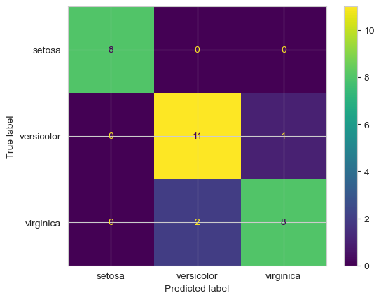

```
versicolor <-> versicolor
setosa <-> setosa
setosa <-> setosa
virginica <-> virginica
versicolor <-> versicolor
setosa <-> setosa
setosa <-> setosa
setosa <-> setosa
virginica <-> virginica
versicolor <-> versicolor
versicolor <-> virginica
setosa <-> setosa
setosa <-> setosa
versicolor <-> versicolor
versicolor <-> versicolor
setosa <-> setosa
virginica <-> virginica
virginica <-> virginica
versicolor <-> versicolor
virginica <-> virginica
virginica <-> virginica
versicolor <-> versicolor
versicolor <-> versicolor
versicolor <-> versicolor
virginica <-> versicolor
virginica <-> virginica
virginica <-> virginica
versicolor <-> versicolor
versicolor <-> versicolor
virginica <-> versicolor
```

```python
# Training & Predicting The Dataset Using Logistic Regression
from sklearn.metrics import accuracy_score,plot_confusion_matrix
from sklearn.linear_model import LogisticRegression
logistic=LogisticRegression()
logistic.fit(X_train,Y_train)
predictLogistic=logistic.predict(X_test)
acc=accuracy_score(Y_test,predictLogistic)*100
print("Model Accuracy: ",acc,"%\n\n")
plot_confusion_matrix(logistic,X_test,Y_test)
plt.show()
print("\n\n")
for i in range(len(predictLogistic)):
  print(Y_test[i],"<->",predictLogistic[i])
```

```
Model Accuracy:  93.33333333333333 %
```

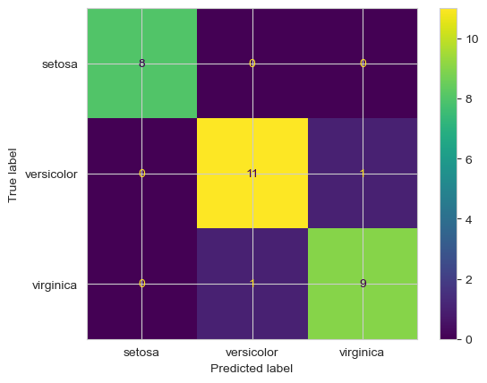

```
versicolor <-> versicolor
setosa <-> setosa
setosa <-> setosa
virginica <-> virginica
versicolor <-> versicolor
setosa <-> setosa
setosa <-> setosa
setosa <-> setosa
virginica <-> virginica
versicolor <-> versicolor
versicolor <-> virginica
setosa <-> setosa
setosa <-> setosa
versicolor <-> versicolor
versicolor <-> versicolor
setosa <-> setosa
virginica <-> virginica
virginica <-> virginica
versicolor <-> versicolor
virginica <-> virginica
virginica <-> virginica
versicolor <-> versicolor
versicolor <-> versicolor
versicolor <-> versicolor
virginica <-> versicolor
virginica <-> virginica
virginica <-> virginica
versicolor <-> versicolor
versicolor <-> versicolor
virginica <-> virginica
```

```python
# Training & Predicting The Dataset Using SVC
from sklearn.metrics import accuracy_score,plot_confusion_matrix
from sklearn.svm import SVC
svc=SVC()
svc.fit(X_train,Y_train)
predictSVM=svc.predict(X_test)
accuracy=accuracy_score(Y_test,predictSVM)*100
print("Model Accuracy: ",accuracy,"%\n\n")
plot_confusion_matrix(svc,X_test,Y_test)
plt.show()
print("\n\n")
for i in range(len(predictSVM)):
  print(Y_test[i],"<->",predictSVM[i])
```